# Diagnoses and cell types

Stephanie J. Spielman

2026-02-05

The goal of this notebook is to look at cell type distributions across libraries to determine how many could be run through `inferCNV`. Specifically, we are interested in seeing the relative numbers of cells intended as `inferCNV` reference vs. query. Cell types were determined to be reference or query based on the sample’s diagnosis, as mapped out in `../references/broad-diagnosis-map.tsv`. We consider a threshold of at least 100 reference cells needed to run `inferCNV`.

## Setup

```r
library(ggplot2)
theme_set(theme_bw())

# settings
options(
  dplyr.summarise.inform = FALSE,
  readr.show_col_types = FALSE
)
```

### Paths

Define directories:

```r
module_dir <- rprojroot::find_root(rprojroot::is_renv_project)
repository_base <- file.path(module_dir, "..", "..")

ref_dir <- file.path(module_dir, "references")
data_dir <- file.path(repository_base, "data", "current")
consensus_dir <- file.path(repository_base, "data", "current", "results", "cell-type-consensus")
consensus_module_dir <- file.path(repository_base, "analyses", "cell-type-consensus")
```

Define paths to input files to read in:

```r
# map broad to submitted diagnoses
diagnosis_map_file <- file.path(ref_dir, "broad-diagnosis-map.tsv")

# map broad diagnoses to cell type groups
diagnosis_celltype_map_file <- file.path(ref_dir, "diagnosis-celltype-groups.tsv")

# map cell type groups to constituent cell types
validation_file <- file.path(
  consensus_module_dir,
  "references",
  "consensus-validation-groups.tsv"
)

# validation palette
palette_url <- "https://raw.githubusercontent.com/AlexsLemonade/scpca-paper-figures/refs/heads/main/palettes/validation-group-palette.tsv"

# metadata files, for getting sample diagnoses
metadata_files <- list.files(
  path = data_dir,
  pattern = "single_cell_metadata\\.tsv$",
  recursive = TRUE,
  full.names = TRUE
)

# TSVs of consensus cell types
consensus_files <- list.files(
  path = consensus_dir,
  pattern = "_processed_consensus-cell-types\\.tsv\\.gz$",
  recursive = TRUE,
  full.names = TRUE
) |>
  # set names to filter on later so we don't read files we don't need
  purrr::set_names(\(x) {
    stringr::str_split_i(basename(x), "_", 1)
  })
```

### Read input data

```r
diagnosis_map <- readr::read_tsv(diagnosis_map_file)
diagnosis_celltype_map <- readr::read_tsv(diagnosis_celltype_map_file)
validation_group_df <- readr::read_tsv(validation_file)
palette_df <- readr::read_tsv(palette_url)
celltype_pal <- palette_df$color |>
  purrr::set_names(palette_df$validation_group_annotation)
celltype_pal["query"] <- celltype_pal["unknown"]
```

```r
 all_library_diagnosis_df <- metadata_files |>
  purrr::map(
    \(file) {
      df <- readr::read_tsv(file) |>
        dplyr::select(scpca_project_id, scpca_library_id, diagnosis, is_cell_line, is_multiplexed) |>
        # have to join here because of multiplexed; inner_join also removes normals
        dplyr::inner_join(diagnosis_map, by = c("diagnosis" = "submitted_diagnosis")) |>
        dplyr::select(-diagnosis, -ontology_id, -human_readable_value) |>
        dplyr::distinct()
  }) |>
  dplyr::bind_rows()

total_libraries <- nrow(all_library_diagnosis_df) # needed for later math

library_diagnosis_df <- all_library_diagnosis_df |>
  # don't consider cell line or multiplexed in this notebook
  # the multiplexed samples were not processed with SCimilarity in OpenScPCA-nf
  dplyr::filter(!is_cell_line, !is_multiplexed)
```

```r
consensus_df <- consensus_files |>
  # only keep libraries in scpca_project_id_diagnosis_df
  purrr::keep_at(library_diagnosis_df$scpca_library_id) |>
  purrr::imap(
    \(file, id) {

      # bump guess_max to kill problems() warnings
      consensus_df <- readr::read_tsv(file, guess_max = 15000)

      # ensure we have the most up-to-date files - aka, with SCimilarity
      stopifnot("Missing SCimilarity in the consensus files" = "scimilarity_celltype_annotation" %in% colnames(consensus_df))

      consensus_df |>
        dplyr::select(
         scpca_project_id = project_id,
         scpca_library_id = library_id,
         barcodes,
         consensus_annotation,
         consensus_ontology
       )
  }) |>
  dplyr::bind_rows()
```

### Prepare data for analysis

Here, we map over each diagnosis group to label each cell as `query` or `reference`. Then, we count the number of each category.

```r
query_reference_df <- unique(library_diagnosis_df$diagnosis_group) |>
  purrr::map(
    \(broad_diagnosis) {

      celltype_groups <- diagnosis_celltype_map |>
        dplyr::filter(diagnosis_group == broad_diagnosis) |>
        tidyr::separate_rows(celltype_groups, sep = ",") |>
        dplyr::pull(celltype_groups) |>
        stringr::str_trim()

      reference_celltypes <- validation_group_df |>
        dplyr::filter(validation_group_annotation %in% celltype_groups) |>
        dplyr::pull(consensus_annotation)

      library_ids <- library_diagnosis_df |>
        dplyr::filter(diagnosis_group == broad_diagnosis) |>
        dplyr::pull(scpca_library_id)

      consensus_df |>
        dplyr::filter(scpca_library_id %in% library_ids) |>
        dplyr::mutate(
          cell_class = ifelse(
            consensus_annotation %in% reference_celltypes,
            "reference",
            "query"
        ))
  }) |>
  dplyr::bind_rows()
```

```r
library_counts_df <- query_reference_df |>
  dplyr::count(scpca_library_id, cell_class) |>
  tidyr::pivot_wider(
    names_from = cell_class,
    values_from = n,
    values_fill = 0
  ) |>
  dplyr::inner_join(library_diagnosis_df, by = "scpca_library_id") |>
  dplyr::select(
    scpca_project_id,
    scpca_library_id,
    diagnosis_group,
    query,
    reference
  )
```

## Analysis

Using a threshold of needing at least 100 reference cells, how many libraries could be run through `inferCNV`?

```r
usable_counts_df <- library_counts_df |>
  dplyr::group_by(diagnosis_group) |>
  dplyr::summarize(
    n_usable = sum(reference >= params$n_reference_threshold),
    total_group_libs = dplyr::n(),
    frac_usable = round(n_usable / total_group_libs, 3)
  ) |>
  dplyr::arrange(desc(total_group_libs)) |>
  dplyr::select(diagnosis_group, total_group_libs, n_usable, frac_usable)

usable_counts_df
```

| diagnosis_group | total_group_libs | n_usable | frac_usable |
| --- | --- | --- | --- |
| Sarcoma | 195 | 82 | 0.421 |
| Brain and CNS | 147 | 86 | 0.585 |
| B-cell leukemia | 129 | 92 | 0.713 |
| T-cell leukemia | 56 | 41 | 0.732 |
| Wilms tumor | 50 | 14 | 0.280 |
| Neuroblastoma | 42 | 23 | 0.548 |
| Acute myeloid leukemia | 40 | 27 | 0.675 |
| Mixed phenotype acute leukemia | 18 | 0 | 0.000 |
| Rhabdoid tumor | 7 | 3 | 0.429 |
| Adrenal cortex carcinoma | 5 | 3 | 0.600 |

[output cut: 4 more lines]

Which diagnosis groups have *no libraries* with sufficient reference cells?

```r
usable_counts_df |>
  dplyr::filter(frac_usable == 0)
```

| diagnosis_group | total_group_libs | n_usable | frac_usable |
| --- | --- | --- | --- |
| Mixed phenotype acute leukemia | 18 | 0 | 0 |
| Gastrointestinal stromal tumor | 2 | 0 | 0 |
| Hepatoblastoma | 1 | 0 | 0 |

It’s not too surprising to see `Mixed phenotype acute leukemia` here since most immune cell types can’t be included in the reference, and the other groups comprise very small numbers of libraries.

In total, this fraction of ScPCA libraries have sufficient reference cells to run through `inferCNV`:

```r
sum(library_counts_df$reference >= params$n_reference_threshold) / total_libraries
```

```
[1] 0.5180556
```

Of the libraries with sufficient reference cells, do any have *fewer* query than reference cells?

```r
usable_libraries_df <- library_counts_df |>
  dplyr::filter(reference >= params$n_reference_threshold)

fewer_query_df <- usable_libraries_df |>
  dplyr::filter(query < params$n_reference_threshold)

fewer_query_df
```

| scpca_project_id | scpca_library_id | diagnosis_group | query | reference |
| --- | --- | --- | --- | --- |
| SCPCP000001 | SCPCL000005 | Brain and CNS | 34 | 292 |
| SCPCP000001 | SCPCL000014 | Brain and CNS | 38 | 728 |
| SCPCP000001 | SCPCL000020 | Brain and CNS | 53 | 358 |
| SCPCP000001 | SCPCL000022 | Brain and CNS | 61 | 391 |
| SCPCP000002 | SCPCL000038 | Brain and CNS | 58 | 250 |

```r
consensus_df |>
  dplyr::filter(scpca_library_id %in% fewer_query_df$scpca_library_id) |>
  dplyr::left_join(validation_group_df, by = c("consensus_ontology", "consensus_annotation")) |>
  dplyr::count(scpca_library_id, validation_group_annotation) |>
  dplyr::arrange(scpca_library_id)
```

| scpca_library_id | validation_group_annotation | n |
| --- | --- | --- |
| SCPCL000005 | B cell | 7 |
| SCPCL000005 | T cell | 83 |
| SCPCL000005 | astrocyte | 5 |
| SCPCL000005 | dendritic cell | 1 |
| SCPCL000005 | glial cell | 14 |
| SCPCL000005 | macrophage | 130 |
| SCPCL000005 | monocyte | 32 |
| SCPCL000005 | myeloid cell | 34 |
| SCPCL000005 | natural killer cell | 4 |
| SCPCL000005 | plasma cell | 1 |

[output cut: 47 more lines]

These libraries are dominated by immune cell types with very few Unknown/tumor cells, but it’s still worth running them through `inferCNV` while being aware that we *may* experience issues with these samples.

## Plot cell types

In this section, we plot the relative contributions of each cell type group in the libraries we can run. We show the relative proportions of consensus cell type groups in the *reference*, and we show all other query cells grouped together in gray. The x-axis is library ids, and the y-axis is the proportion of each cell type group.

```r
plot_df <- query_reference_df |>
  dplyr::filter(scpca_library_id %in% usable_libraries_df$scpca_library_id) |>
  dplyr::left_join(validation_group_df, by = c("consensus_ontology", "consensus_annotation")) |>
  dplyr::select(
    scpca_project_id,
    scpca_library_id,
    barcodes,
    cell_class,
    validation_group_annotation
  ) |>
  dplyr::mutate(
    label = ifelse(
      cell_class == "query",
      "query",
      validation_group_annotation
    ),
    # move "query" first
    label = forcats::fct_relevel(label, "query", after = 0)
  )
```

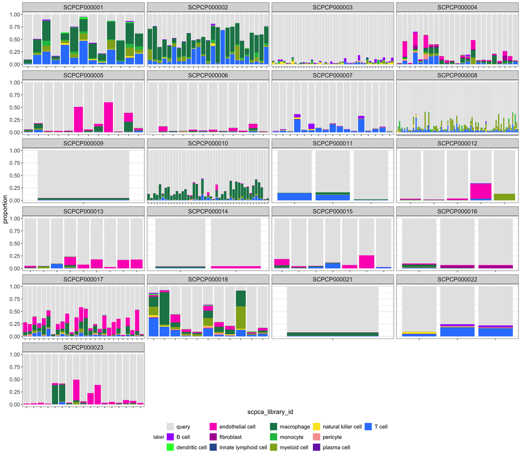

```r
ggplot(plot_df) +
  aes(x = scpca_library_id, fill = label) +
  geom_bar(position = "fill") +
  scale_fill_manual(values = celltype_pal) +
  facet_wrap(
    vars(scpca_project_id),
    scales = "free_x",
    ncol = 4
  ) +
  ylab("proportion") +
  theme(
    axis.text.x = element_blank(),
    axis.text.y = element_text(size = 12),
    axis.title = element_text(size = 14),
    strip.text = element_text(size = 13),
    legend.text = element_text(size = 12),
    legend.position = "bottom"
  )
```

## Conclusions

We are able to run about 50% of libraries through `inferCNV`, based on consensus cell types derived from `SingleR`, `CellAssign`, and `SCimilarity` labels. Most broad diagnosis groups are represented, except `Mixed phenotype acute leukemia` (n=18) and a handful of other solid tumors (n=3 among Gastrointestinal stromal tumor and Hepatoblastoma). All eligible projects are represented as well.

Note that it was not possible to fully assess multiplexed libraries here since they did not undergo `SCimilarity` (and hence their consensus cell types are not updated) inference in `OpenScPCA-nf`. They will be included when running through `scpca-nf`, however, assuming they have sufficient reference cells; it is important to bear in mind that these libraries would effectively be using pooled references in `inferCNV`, since we did not demultiplex libraries.